# Homework 7

Yu-Jen Lin

#### b04b01036@ntu.edu.tw

#### ——————————————————————————————————————————————————–

#### 1. Use the “dominant” copepod species data (from HW1). Perform cluster analysis of stations based on percent composition data of the dominant species and tell your story about these copepod data.You can try to run the example analysis using the environmental data from HW3 to familiarize yourself with cluster analysis.

###### – Try to determine the effects of different distance measures

###### – Try to compare the results between different cluster algorithms

###### – Determine final number of clusters and describe differences among them

#### ——————————————————————————————————————————————————–

#### Retrieve the dominant species from HW1

```r
dominant = read.csv("~/R/dominant_HW1.csv",row.names = 1,header=T) # examples HW1
```

#### Installing packages

```r
# install.packages("vegan")
# install.packages("cluster")
# install.packages("fpc")
# install.packages('ggfortify')

library(ggfortify)
library(vegan)
library(cluster)
library(fpc)
library(ggfortify)
```

## Distance

```r
#standardize data
data = t(dominant)
data.std = scale(data)   # each column -> standardize (z score) by columns

#compute distance matrix
dist.euclidean = dist(data.std,method='euclidean')
dist.maximum = dist(data.std,method='maximum')
dist.manhattan = dist(data.std,method='manhattan')
dist.canberra = dist(data.std,method='canberra')
dist.binary = dist(data.std,method='binary')
dist.minkowski = dist(data.std,method='minkowski')
dist.bray_curtis  = dist.manhattan / dist.maximum # Though there's no direct methods we can use in dist function, we can still build one to calculate the bray_curtis distance matrix.
```

#### ——————————————————————————————————————————————————–

# Conduct a Nonhierarchical Clustering (NHC)

#### ——————————————————————————————————————————————————–

## Try to determine the effects of different distance measures

#### Distance method 1/6 : euclidean

```r
dist.METHOD = dist.euclidean

# Determine number of clusters
## by maximizing the distance between cluster centers while minimizing the within-cluster variation
## Need to write a program for making scree plot and silhouette width

km.result <- c() # Total within groups sum of squares
for(i in 1:15){
  km <- kmeans(dist.METHOD, centers = i, nstart = 25) # nstart: random sets that should be chosen # minimizing km

  # minimize k means # total within groups sum of squares
  km.result[i] <- km$tot.withinss # = sum(kmeans$withinss)
}
sil.result <- c()
for(i in 2:15){ # silhouette of 1 cluster is NA, thus I start from 2 clusters
  km <- kmeans(dist.METHOD, centers = i, nstart = 25) # nstart: random sets that should be chosen # minimizing km

  # silhouette width # maximize average silhouette
  ss = silhouette(km$cluster, dist(dist.METHOD)) # clusters >= 2
  sil.result[i] = mean(ss[,3])
}

# RESULTS
km.result.euclidean <- km.result
sil.result.euclidean <- sil.result
```

#### Distance method 2/6 : maximum

```r
dist.METHOD = dist.maximum

# Determine number of clusters
## by maximizing the distance between cluster centers while minimizing the within-cluster variation
## Need to write a program for making scree plot and silhouette width

km.result <- c() # Within cluster sum
for(i in 1:15){
  km <- kmeans(dist.METHOD, centers = i, nstart = 25) # nstart: random sets that should be chosen # minimizing km

  # minimize k means # total within groups sum of squares
  km.result[i] <- km$tot.withinss # = sum(kmeans$withinss)
}
sil.result <- c()
for(i in 2:15){ # silhouette of 1 cluster is NA, thus I start from 2 clusters
  km <- kmeans(dist.METHOD, centers = i, nstart = 25) # nstart: random sets that should be chosen # minimizing km

  # silhouette width # maximize average silhouette
  ss = silhouette(km$cluster, dist(dist.METHOD)) # clusters >= 2
  sil.result[i] = mean(ss[,3])
}

# RESULTS
km.result.maximum <- km.result
sil.result.maximum <- sil.result
```

#### Distance method 3/6 : manhattan

```r
dist.METHOD = dist.manhattan

# Determine number of clusters
## by maximizing the distance between cluster centers while minimizing the within-cluster variation
## Need to write a program for making scree plot and silhouette width

km.result <- c() # Within cluster sum
for(i in 1:15){
  km <- kmeans(dist.METHOD, centers = i, nstart = 25) # nstart: random sets that should be chosen # minimizing km

  # minimize k means # total within groups sum of squares
  km.result[i] <- km$tot.withinss # = sum(kmeans$withinss)
}
sil.result <- c()
for(i in 2:15){ # silhouette of 1 cluster is NA, thus I start from 2 clusters
  km <- kmeans(dist.METHOD, centers = i, nstart = 25) # nstart: random sets that should be chosen # minimizing km

  # silhouette width # maximize average silhouette
  ss = silhouette(km$cluster, dist(dist.METHOD)) # clusters >= 2
  sil.result[i] = mean(ss[,3])
}

# RESULTS
km.result.manhattan <- km.result
sil.result.manhattan <- sil.result
```

#### Distance method 4/6 : canberra

```r
dist.METHOD = dist.canberra

# Determine number of clusters
## by maximizing the distance between cluster centers while minimizing the within-cluster variation
## Need to write a program for making scree plot and silhouette width

km.result <- c() # Within cluster sum
for(i in 1:15){
  km <- kmeans(dist.METHOD, centers = i, nstart = 25) # nstart: random sets that should be chosen # minimizing km

  # minimize k means # total within groups sum of squares
  km.result[i] <- km$tot.withinss # = sum(kmeans$withinss)
}
sil.result <- c()
for(i in 2:15){ # silhouette of 1 cluster is NA, thus I start from 2 clusters
  km <- kmeans(dist.METHOD, centers = i, nstart = 25) # nstart: random sets that should be chosen # minimizing km

  # silhouette width # maximize average silhouette
  ss = silhouette(km$cluster, dist(dist.METHOD)) # clusters >= 2
  sil.result[i] = mean(ss[,3])
}

# RESULTS
km.result.canberra <- km.result
sil.result.canberra <- sil.result
```

#### Distance method 5/6 : minkowski

```r
dist.METHOD = dist.minkowski

# Determine number of clusters
## by maximizing the distance between cluster centers while minimizing the within-cluster variation
## Need to write a program for making scree plot and silhouette width

km.result <- c() # Within cluster sum
for(i in 1:15){
  km <- kmeans(dist.METHOD, centers = i, nstart = 25) # nstart: random sets that should be chosen # minimizing km

  # minimize k means # total within groups sum of squares
  km.result[i] <- km$tot.withinss # = sum(kmeans$withinss)
}
sil.result <- c()
for(i in 2:15){ # silhouette of 1 cluster is NA, thus I start from 2 clusters
  km <- kmeans(dist.METHOD, centers = i, nstart = 25) # nstart: random sets that should be chosen # minimizing km

  # silhouette width # maximize average silhouette
  ss = silhouette(km$cluster, dist(dist.METHOD)) # clusters >= 2
  sil.result[i] = mean(ss[,3])
}

# RESULTS
km.result.minkowski <- km.result
sil.result.minkowski <- sil.result
```

#### Distance method 6/6 : bray_curtis

```r
dist.METHOD = dist.bray_curtis

# Determine number of clusters
## by maximizing the distance between cluster centers while minimizing the within-cluster variation
## Need to write a program for making scree plot and silhouette width

km.result <- c() # Within cluster sum
for(i in 1:15){
  km <- kmeans(dist.METHOD, centers = i, nstart = 25) # nstart: random sets that should be chosen # minimizing km

  # minimize k means # total within groups sum of squares
  km.result[i] <- km$tot.withinss # = sum(kmeans$withinss)
}
sil.result <- c()
for(i in 2:15){ # silhouette of 1 cluster is NA, thus I start from 2 clusters
  km <- kmeans(dist.METHOD, centers = i, nstart = 25) # nstart: random sets that should be chosen # minimizing km

  # silhouette width # maximize average silhouette
  ss = silhouette(km$cluster, dist(dist.METHOD)) # clusters >= 2
  sil.result[i] = mean(ss[,3])
}

# RESULTS
km.result.bray_curtis <- km.result
sil.result.bray_curtis <- sil.result
```

## Determine how many clusters

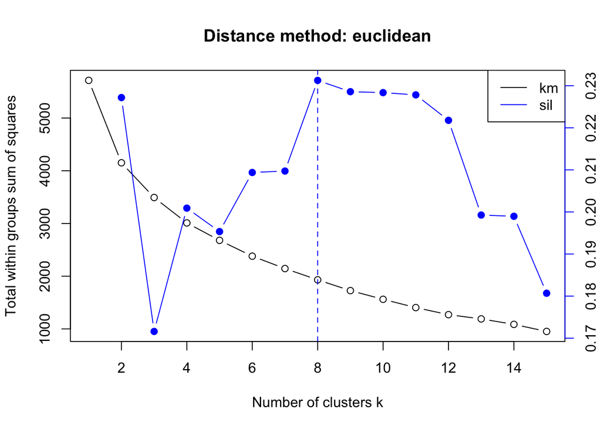

```r
plot(km.result.euclidean, main="Distance method: euclidean", type='b', col="black", ylab="Total within groups sum of squares", xlab="Number of clusters k")
par(new = T)
plot(1:15, sil.result.euclidean, type='b', pch=19, frame=FALSE, ylab='', xlab='', axes=F, col="blue")
axis(side = 4, col="blue")
mtext(side = 4, line = 2, text="Average silhouette widths",col="blue")
abline(v=which.max(sil.result.euclidean), lty=2, col="blue")
legend("topright", c("km","sil"), col=c("black","blue"), lty=1)
```

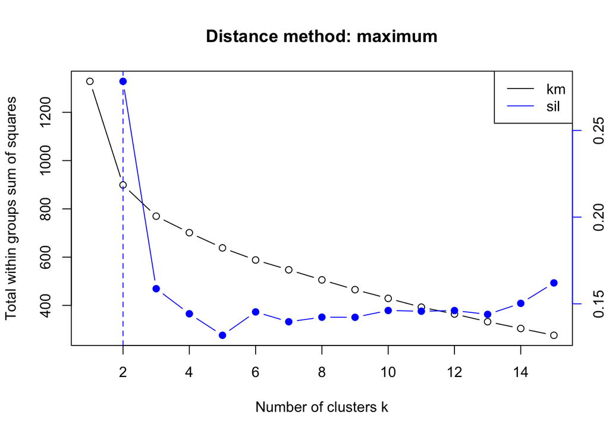

```r
plot(km.result.maximum, main="Distance method: maximum", type='b', col="black", ylab="Total within groups sum of squares", xlab="Number of clusters k")
par(new = T)
plot(1:15, sil.result.maximum, type='b', pch=19, frame=FALSE, ylab='', xlab='', axes=F, col="blue")
axis(side = 4, col="blue")
mtext(side = 4, line = 2, text="Average silhouette widths",col="blue")
abline(v=which.max(sil.result.maximum), lty=2, col="blue")
legend("topright", c("km","sil"), col=c("black","blue"), lty=1)
```

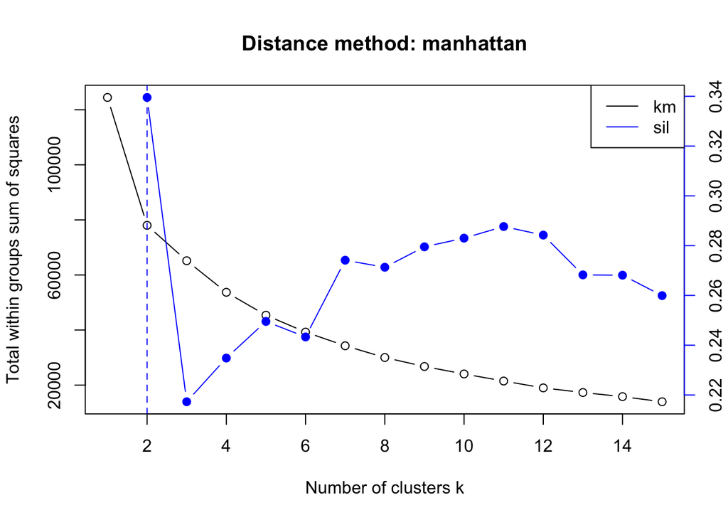

```r
plot(km.result.manhattan, main="Distance method: manhattan", type='b', col="black", ylab="Total within groups sum of squares", xlab="Number of clusters k")
par(new = T)
plot(1:15, sil.result.manhattan, type='b', pch=19, frame=FALSE, ylab='', xlab='', axes=F, col="blue")
axis(side = 4, col="blue")
mtext(side = 4, line = 2, text="Average silhouette widths",col="blue")
abline(v=which.max(sil.result.manhattan), lty=2, col="blue")
legend("topright", c("km","sil"), col=c("black","blue"), lty=1)
```

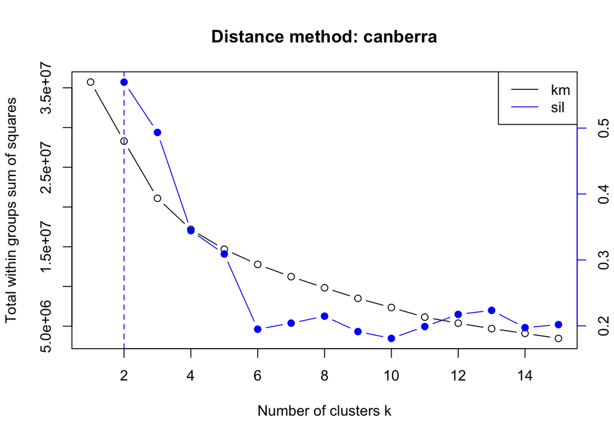

```r
plot(km.result.canberra, main="Distance method: canberra", type='b', col="black", ylab="Total within groups sum of squares", xlab="Number of clusters k")
par(new = T)
plot(1:15, sil.result.canberra, type='b', pch=19, frame=FALSE, ylab='', xlab='', axes=F, col="blue")
axis(side = 4, col="blue")
mtext(side = 4, line = 2, text="Average silhouette widths",col="blue")
abline(v=which.max(sil.result.canberra), lty=2, col="blue")
legend("topright", c("km","sil"), col=c("black","blue"), lty=1)
```

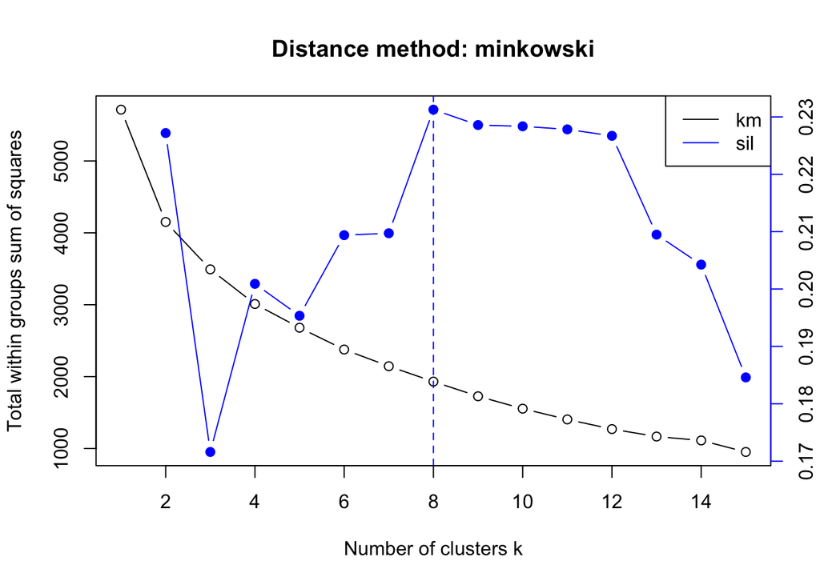

```r
plot(km.result.minkowski, main="Distance method: minkowski", type='b', col="black", ylab="Total within groups sum of squares", xlab="Number of clusters k")
par(new = T)
plot(1:15, sil.result.minkowski, type='b', pch=19, frame=FALSE, ylab='', xlab='', axes=F, col="blue")
axis(side = 4, col="blue")
mtext(side = 4, line = 2, text="Average silhouette widths",col="blue")
abline(v=which.max(sil.result.minkowski), lty=2, col="blue")
legend("topright", c("km","sil"), col=c("black","blue"), lty=1)
```

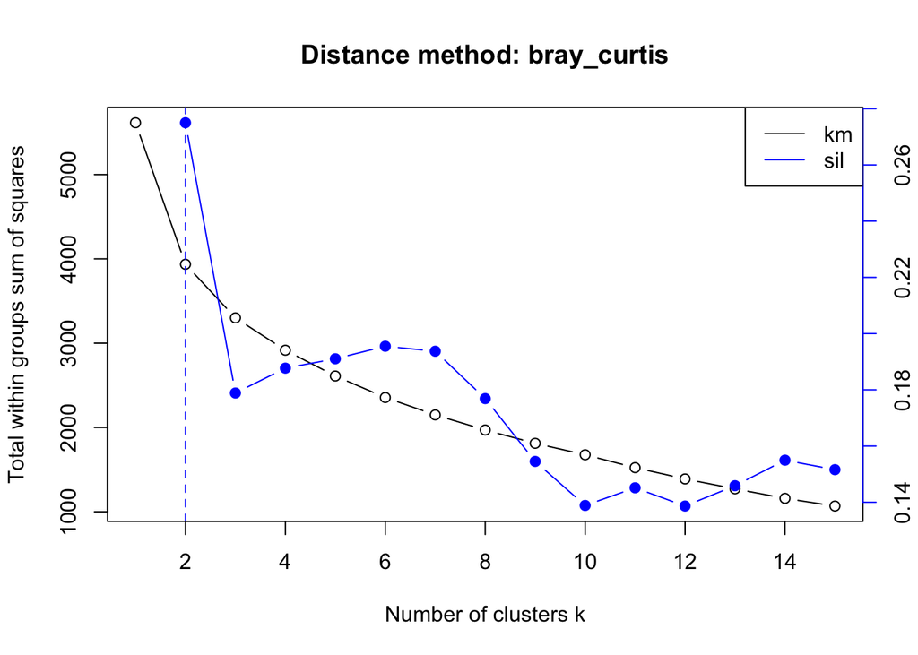

```r
plot(km.result.bray_curtis, main="Distance method: bray_curtis", type='b', col="black", ylab="Total within groups sum of squares", xlab="Number of clusters k")
par(new = T)
plot(1:15, sil.result.bray_curtis, type='b', pch=19, frame=FALSE, ylab='', xlab='', axes=F, col="blue")
axis(side = 4, col="blue")
mtext(side = 4, line = 2, text="Average silhouette widths",col="blue")
abline(v=which.max(sil.result.bray_curtis), lty=2, col="blue")
legend("topright", c("km","sil"), col=c("black","blue"), lty=1)
```

## Choose k=2 and plot the results

In last step, most of the result graphs show that k=2 has the highest silhouette widths. Thus, I choose k=2 to do futher clustering.

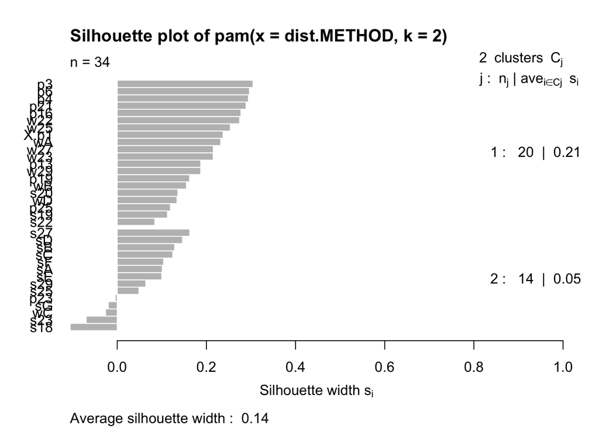

```r
#compute k-means NHC around 2 mediods (clusters)

##  Partitioning Around Medoids / Partitioning (clustering) of the data into k clusters “around medoids”, a more robust version of K-means.
dist.METHOD <- dist.euclidean
y.pam = pam(dist.METHOD,k=2)
plot(y.pam)
```

```r
summary(y.pam) # 內容Objective function:,Isolated clusters:
```

```
## Medoids:
##      ID
## [1,] "6"  "p16"
## [2,] "22" "sD"
## Clustering vector:
## X.p1   p3   p4   p6  p13  p16  p19  p21  p23  p25  s18  s19  s20  s22  s23
##    1    1    1    1    1    1    1    1    2    1    2    1    1    1    2
##  s25  s27  s29   sA   sB   sC   sD   sE   sF   sG  w22  w23  w25  w27  w29
##    2    2    2    2    2    2    2    2    2    2    1    1    1    1    1
##   wA   wB   wC   wD
##    1    1    2    1
## Objective function:
##    build     swap
## 6.383422 6.383422
##
## Numerical information per cluster:
##      size max_diss  av_diss diameter separation
## [1,]   20 9.623349 6.197305 11.84048   5.708589
## [2,]   14 9.833764 6.649304 13.14865   5.708589
##
## Isolated clusters:
##  L-clusters: character(0)
##  L*-clusters: character(0)
##
## Silhouette plot information:
##      cluster neighbor   sil_width
## p3         1        2  0.30460443
## p6         1        2  0.29664115
## p4         1        2  0.29417177
## p21        1        2  0.28881878
## p16        1        2  0.27749784
## w22        1        2  0.27456711
## w25        1        2  0.25364255
## X.p1       1        2  0.23741842
## wA         1        2  0.23212092
## w27        1        2  0.21559589
## w23        1        2  0.21528774
## p13        1        2  0.18741737
## w29        1        2  0.18721181
## p19        1        2  0.16240073
```

[output cut: 13 more lines]

```
## s29        2        1  0.06400146
## s25        2        1  0.04869388
## p23        2        1 -0.00454027
## sG         2        1 -0.02005056
## wC         2        1 -0.02610320
## s23        2        1 -0.06965507
## s18        2        1 -0.10554711
## Average silhouette width per cluster:
## [1] 0.20846711 0.05386323
## Average silhouette width of total data set:
## [1] 0.1448067
##
## Available components:
## [1] "medoids"    "id.med"     "clustering" "objective"  "isolation"
## [6] "clusinfo"   "silinfo"    "diss"       "call"
```

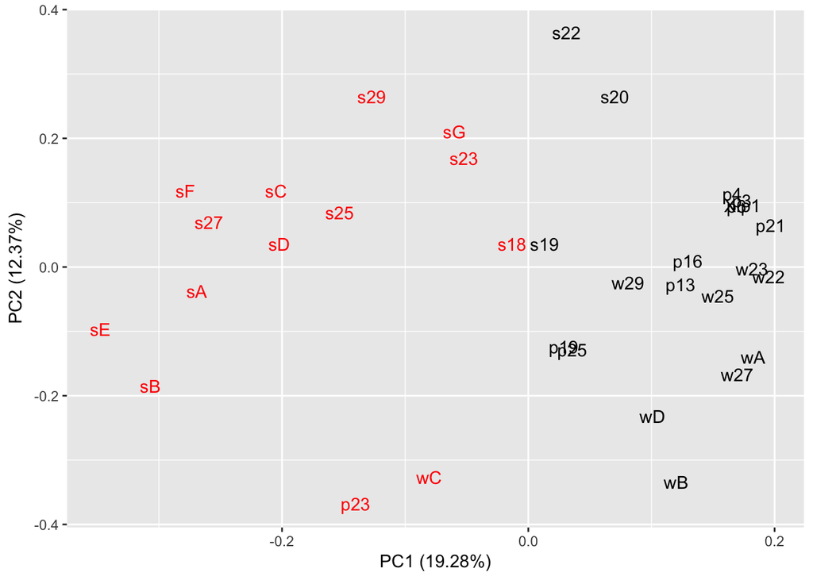

```r
## Clustering Large Applications
y.clara = clara(data.std,k=2, metric="euclidean")

autoplot(prcomp(data.std), data = data.std, colour=y.pam$clustering,label=T, shape=F)
```

```r
#evaluate cluster stability
y.eucl.boot = clusterboot(data.std, B=100, metric='euclidean', bootmethod=c('boot','subset'), clustermethod=claraCBI, usepam=TRUE, k=2, count=FALSE)
print(y.eucl.boot) # dissolved < 0.5, recovered > 0.75
```

```
## * Cluster stability assessment *
## Cluster method:  clara/pam
## Full clustering results are given as parameter result
## of the clusterboot object, which also provides further statistics
## of the resampling results.
## Number of resampling runs:  100
##
## Number of clusters found in data:  2
##
##  Clusterwise Jaccard bootstrap (omitting multiple points) mean:
## [1] 0.8363571 0.8010964
## dissolved:
## [1]  7 11
## recovered:
## [1] 77 66
##  Clusterwise Jaccard subsetting mean:
## [1] 0.8094865 0.7621266
## dissolved:
## [1] 12 20
## recovered:
## [1] 70 58
```

#### ——————————————————————————————————————————————————–

# Conduct a Hierarchical Clustering (HC)

#### ——————————————————————————————————————————————————–

## Various hierarchical joining algorithms

```r
dist.METHOD = dist.euclidean # in this part, I only show the results of using euclidean method.

## 1. bottom-up -> Hierarchical Clustering
y.eucl.hclust.ward.D = hclust(dist.METHOD,method='ward.D')
y.eucl.hclust.ward.D2 = hclust(dist.METHOD,method='ward.D2')
y.eucl.hclust.single = hclust(dist.METHOD,method='single')
y.eucl.hclust.complete = hclust(dist.METHOD,method='complete')
y.eucl.hclust.average = hclust(dist.METHOD,method='average') # = UPGMA
y.eucl.hclust.mcquitty = hclust(dist.METHOD,method='mcquitty') # = WPGMA
y.eucl.hclust.median = hclust(dist.METHOD,method='median') # = WPGMC
y.eucl.hclust.centroid = hclust(dist.METHOD,method='centroid') # = UPGMC

## 2. bottom-up 2/2 -> Agglomerative Nesting (Hierarchical Clustering)
y.eucl.agnes.ward = agnes(dist.METHOD,method="ward") # (Ward's method),
y.eucl.agnes.average = agnes(dist.METHOD,method="average") # ([unweighted pair-]group [arithMetic] average method, aka ‘UPGMA’),
y.eucl.agnes.single = agnes(dist.METHOD,method="single") # (single linkage),
y.eucl.agnes.complete = agnes(dist.METHOD,method="complete") #  (complete linkage),
y.eucl.agnes.weighted = agnes(dist.METHOD,method="weighted") # (weighted average linkage, aka ‘WPGMA’), its generalization
y.eucl.agnes.gaverage = agnes(dist.METHOD,method="gaverage") # a generalized "average" aka “flexible UPGMA” method also using the Lance-Williams formula and par.method.

## 3. top-down -> DIvisive ANAlysis Clustering
y.eucl.diana = diana(dist.METHOD)
```

## Dendrogram / When k=2:

Most of the clustering results show that data collected in the same season are more prone to be group together. Summer data almost form one group. And spring and winter stay in one group. As a result, it might imply that the species composotions in summer is quite different from the other two.

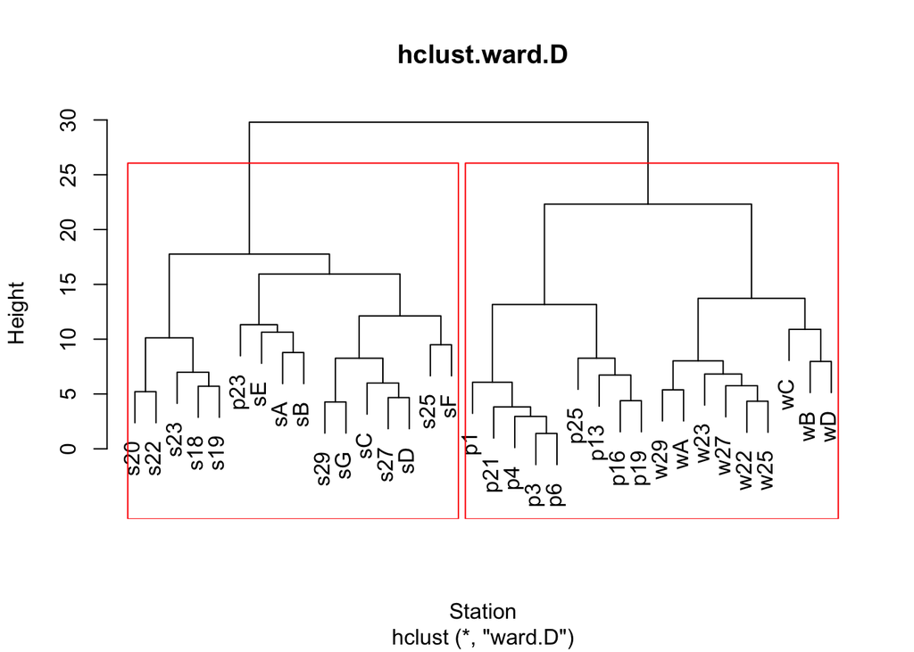

```r
names<-c("p1","p3","p4","p6","p13","p16","p19","p21","p23","p25","s18","s19","s20","s22","s23","s25","s27","s29","sA","sB","sC","sD","sE","sF","sG","w22","w23","w25","w27","w29","wA","wB","wC","wD")

## 1. bottom-up -> Hierarchical Clustering
plot(y.eucl.hclust.ward.D,main='hclust.ward.D',xlab='Station',labels=names)
rect.hclust(y.eucl.hclust.ward.D,k=2) #cut by #clusters
```

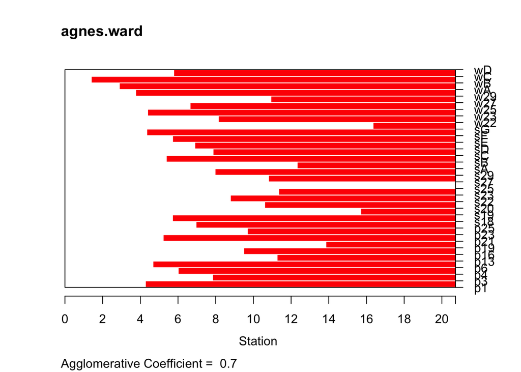

```r
## 2. bottom-up 2/2 -> Agglomerative Nesting (Hierarchical Clustering)
plot(y.eucl.agnes.ward,main='agnes.ward',xlab='Station',labels=names)
```

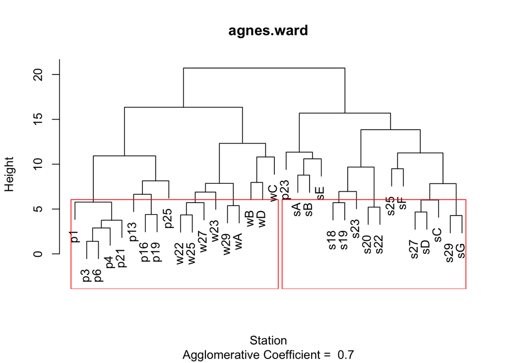

```r
rect.hclust(y.eucl.agnes.ward,k=2) #cut by #clusters
```

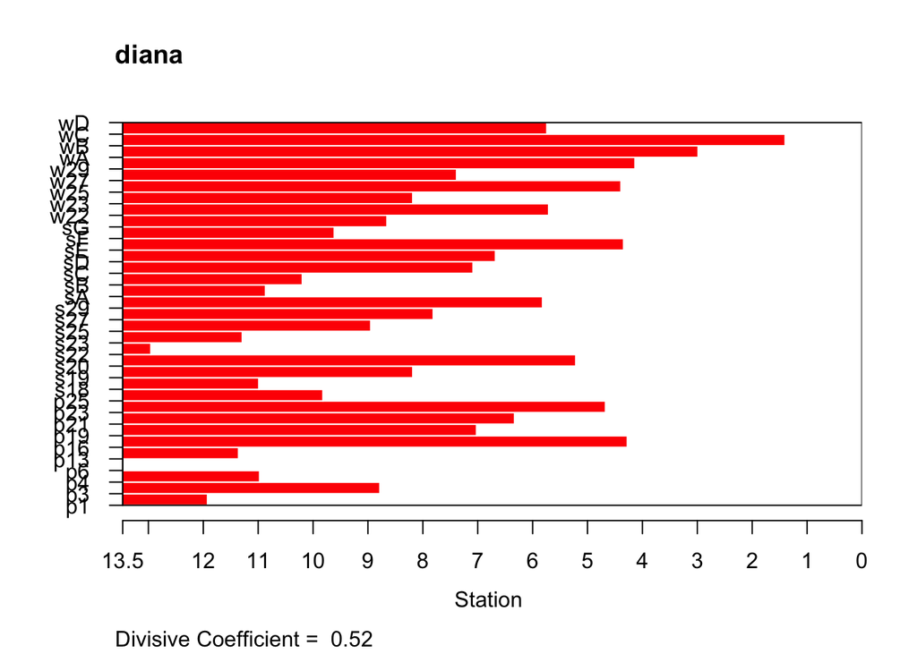

```r
## 3. top-down -> DIvisive ANAlysis Clustering
plot(y.eucl.diana,main='diana',xlab='Station',labels=names)
```

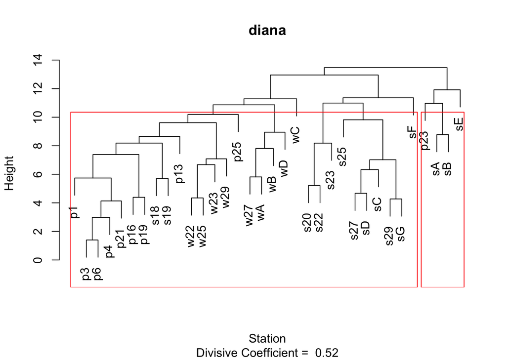

```r
rect.hclust(y.eucl.diana,k=2) #cut by #clusters
```

## Dendrogram / When k=3:

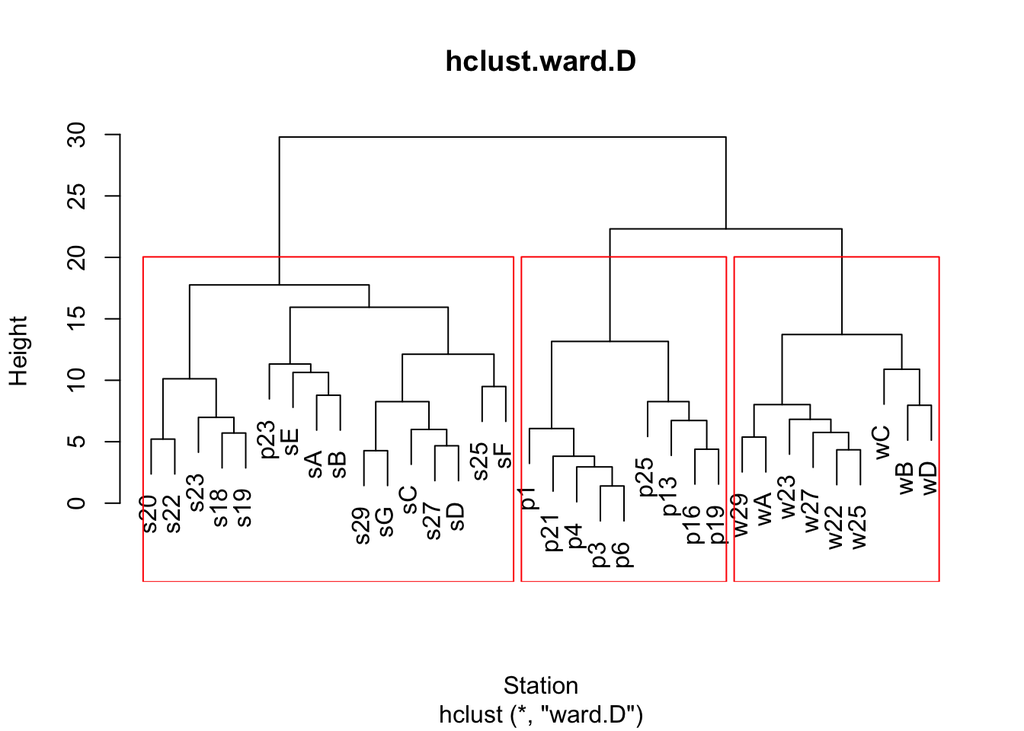

```r
## 1. bottom-up -> Hierarchical Clustering
plot(y.eucl.hclust.ward.D,main='hclust.ward.D',xlab='Station',labels=names)
rect.hclust(y.eucl.hclust.ward.D,k=3) #cut by #clusters
```

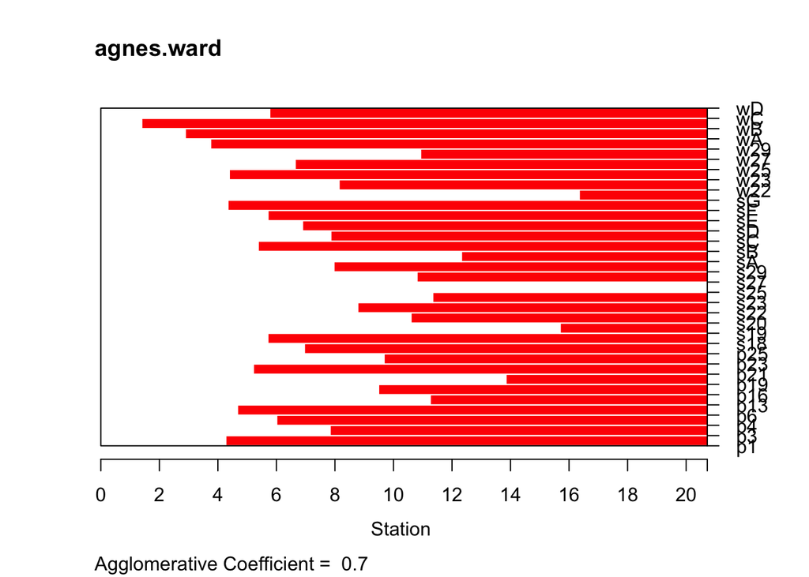

```r
## 2. bottom-up 2/2 -> Agglomerative Nesting (Hierarchical Clustering)
plot(y.eucl.agnes.ward,main='agnes.ward',xlab='Station',labels=names)
```

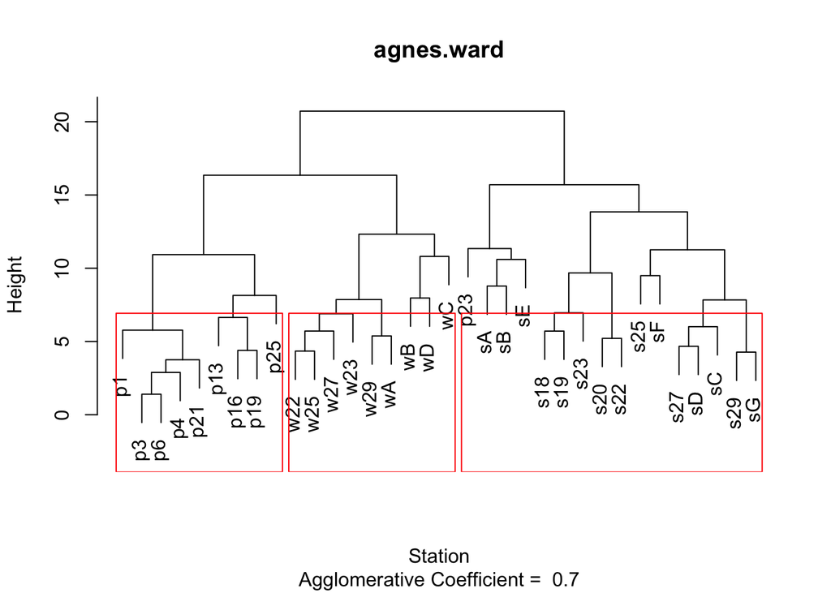

```r
rect.hclust(y.eucl.agnes.ward,k=3) #cut by #clusters
```

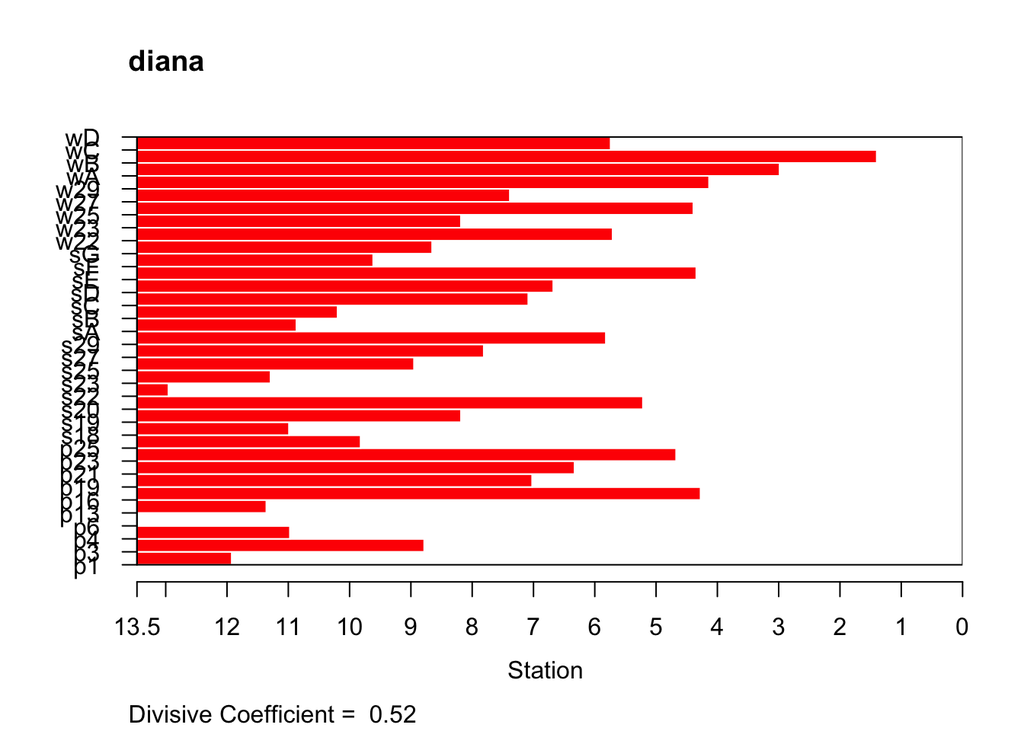

```r
## 3. top-down -> DIvisive ANAlysis Clustering
plot(y.eucl.diana,main='diana',xlab='Station',labels=names)
```

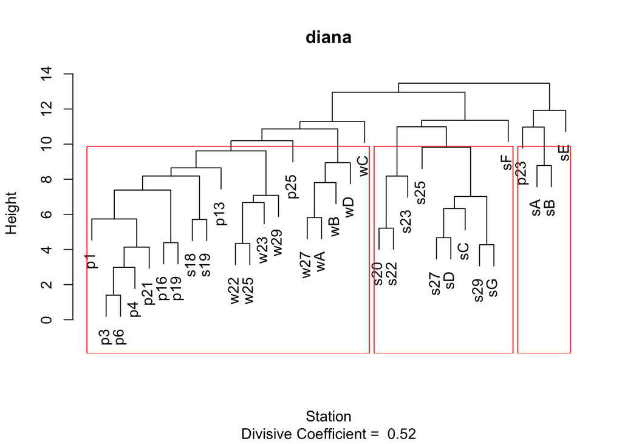

```r
rect.hclust(y.eucl.diana,k=3) #cut by #clusters
```